# instruction

### Set Up:

- https://code.visualstudio.com/Download, https://www.python.org/downloads/
- make sure python exists or is installed on your computer
- install Jupyter Notebook and Python in the Extension tab
- create notebook by naming the file name.ipynb
- make sure an appropriate Python interpreter is chosen (see upper right tab)

Referencable Docs: https://code.visualstudio.com/docs/datascience/jupyter-notebooks

Keyboard Shortcuts:

- Windows: https://code.visualstudio.com/shortcuts/keyboard-shortcuts-windows.pdf
- MacOS: https://code.visualstudio.com/shortcuts/keyboard-shortcuts-macos.pdf
- Linux: https://code.visualstudio.com/shortcuts/keyboard-shortcuts-linux.pdf

### Python Interpreter & Environment:

You can create different python environments for different projects. All of these environments can contain different types of python packages or dependencies. We will focus on the basics for now, but here's a link to resources for getting started. https://code.visualstudio.com/docs/python/environments

```python
# macOS/Linux
# You may need to run sudo apt-get install python3-venv first
!python3 -m venv .venv

# Windows
# You can also use py -3 -m venv .venv
!python -m venv .venv
```

Jupyter notebooks 'like' conda environments. So, for trouble shooting purposes, it might be worth creating a conda environment. Alternatively, you can use a pre-exsiting conda environment if you've created one before in anaconda (VSCode is good at recognizing environments so you don't have to worry about doing anything too fancy). For the sake of demonstration, here is an example of how to create a conda environment:

```python
! conda create -n new-env python=3.9 # scipy=0.15.0 astroid babel
```

# Header

## smaller header

### smallest header

body, *italic*, **bold**

- bullet
- another bullet

bash is a language we can use inside the cells of our notebooks with an exclamation mark or in the terminal without one. We will use bash primarily to install packages. We can also use bash for python tools that use Command Line Interface. It is good to use bash in notebooks for reproducibility.

Git is the best example of Command Line Interface (CLI). CLI is commonly used with API's, something you might want to familiarize for future data collection. Here are some useful CLI's if you are interested: https://docs.python-guide.org/scenarios/cli/

### Basic Terminal Commands:

```python
# ! pwd
# ! ls
# ! cd
```

### Package Installation:

```python
! python --version
```

```
Python 3.7.7
```

```python
! pip install [package]
```

```python
! pip install pandas numpy matplotlib plotnine statsmodels
```

```python
# https://medium.com/analytics-vidhya/built-in-datasets-in-python-24adca42012c
! pip install -U scikit-learn
```

A requirements text 'contains' multiple python packages and dependencies necessary for a particular type of project. requirements.txt is typically a text file included in a package or repository. pip installs on requirements texts can be more convenient than pip installing individual packages in some cases. You can install and create requirements texts using the code below

```python
! pip install -r requirements.txt
# first, create a blank requirements.txt file in your directory, then run
! pip freeze > requirements.txt
```

Good for copying a repository. Sometimes python packages will have you do this instead of a pip install. We won't go into using git today, but you can use git in the terminal to remotely copy, make changes, and send changes to a github repository.

```python
! git clone [repository name]
```

### Using Python

```python
print("hello world")
```

```
hello world
```

package imports can be contained in a separate cell, just rememeber to run it when working on projects

```python
import pandas as pd
import numpy as np
import matplotlib.pyplot as plt
import plotnine as p9
# from statsmodels import datasets
```

```python
# print(datasets.cancer.NOTE)
```

[output not shown]

```python
df = pd.read_csv("verified_copy.csv")
df.head()
```

|  | Unnamed: 0 | id | conversation_id | created_at | date | time | timezone | user_id | username | name | ... | urls | photos | replies_count | retweets_count | likes_count | hashtags | cashtags | link | polarity | subjectivity |
| --- | --- | --- | --- | --- | --- | --- | --- | --- | --- | --- | --- | --- | --- | --- | --- | --- | --- | --- | --- | --- | --- |
| 0 | 0 | 1550999167748694017 | 1550999167748694017 | 2022-07-23 17:19:52 PDT | 2022-07-23 | 17:19:52 | -700 | 2371339658 | repjimmygomez | Rep. Jimmy Gomez | ... | [] | ['https://pbs.twimg.com/media/FYZBg2dWIAIBjyN.... | 0 | 5 | 14 | ['ca34', 'koreatown'] | [] | https://twitter.com/RepJimmyGomez/status/15509... | 0.442519 | 0.484091 |
| 1 | 1 | 1542319507724812288 | 1542319507724812288 | 2022-06-29 18:30:00 PDT | 2022-06-29 | 18:30:00 | -700 | 3638215945 | mirrornow | Mirror Now | ... | ['https://bit.ly/3NvXtJI'] | [] | 0 | 1 | 1 | [] | [] | https://twitter.com/MirrorNow/status/154231950... | -0.150000 | 0.400000 |
| 2 | 2 | 1532397095683928065 | 1532397095683928065 | 2022-06-02 09:21:52 PDT | 2022-06-02 | 9:21:52 | -700 | 587852239 | tracylehrnews | Tracy Lehr | ... | ['https://keyt.com/news/education/2022/06/01/s... | [] | 0 | 0 | 2 | ['munger'] | [] | https://twitter.com/TracyLehrNews/status/15323... | 0.000000 | 0.000000 |
| 3 | 3 | 1532183679719444480 | 1532183679719444480 | 2022-06-01 19:13:50 PDT | 2022-06-01 | 19:13:50 | -700 | 587852239 | tracylehrnews | Tracy Lehr | ... | ['https://keyt.com/news/education/2022/06/01/s... | [] | 0 | 1 | 0 | ['munger'] | [] | https://twitter.com/TracyLehrNews/status/15321... | 0.000000 | 0.000000 |
| 4 | 4 | 1532111273801920513 | 1532111273801920513 | 2022-06-01 14:26:07 PDT | 2022-06-01 | 14:26:07 | -700 | 1259979349 | johnpalminteri | John Palminteri | ... | [] | ['https://pbs.twimg.com/media/FUMmxv9UYAAiFDi.... | 3 | 3 | 3 | [] | [] | https://twitter.com/JohnPalminteri/status/1532... | 0.000000 | 0.000000 |

5 rows × 24 columns

```python
df = df[["date","tweet","replies_count","likes_count","polarity"]]
df.head()
```

|  | date | tweet | replies_count | likes_count | polarity |
| --- | --- | --- | --- | --- | --- |
| 0 | 2022-07-23 | Great to see so many new and familiar faces at... | 0 | 14 | 0.442519 |
| 1 | 2022-06-29 | Munger News: The video which has gone viral sh... | 0 | 1 | -0.150000 |
| 2 | 2022-06-02 | Students host #Munger Hall response panel htt... | 0 | 2 | 0.000000 |
| 3 | 2022-06-01 | Students host #Munger Hall response panel htt... | 0 | 0 | 0.000000 |
| 4 | 2022-06-01 | Proposed to be 11 stories for 4500 students wi... | 3 | 3 | 0.000000 |

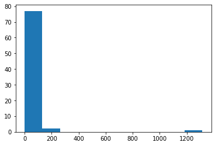

```python
likes = df["likes_count"].to_list()
# likes = [x for x in likes if x <= 200]
# likes = [x for x in likes if x <= 100]

# print(likes)
plt.hist(likes)
plt.show()
```

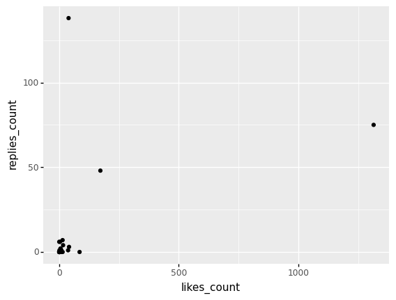

```python
# Create
plot = p9.ggplot(data=df, mapping=p9.aes(x='likes_count', y='replies_count'))

# Draw the plot
plot + p9.geom_point()
```

more in depth example. probably won't go over

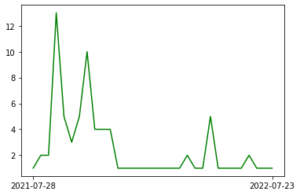

```python
# df['new_date'] = df['date'].date()
df['date'] = pd.to_datetime(df["date"]).dt.strftime('%Y-%m-%d')
# print(df['date'].to_list())

df['freq_count'] = df.groupby('date')['date'].transform('count')
df = df.drop_duplicates(subset='date')

dates = df['date'].to_list()
dates = dates[::-1]
freqs = df['freq_count'].to_list()
freqs = freqs[::-1]
plt.plot_date(dates, freqs, 'g')
plt.xticks([dates[0], dates[-1]], visible=True, rotation="horizontal")
plt.show()
```

### Exportation:

You can export this notebook to PDF/HTML (similarly to Jupyter Notebooks in Anaconda or R Markdown). However, you must have a latex engine installed inorder to export notebooks. You can export the notebook after clicking the export tab (found near the top of the screen) and selecting your desired format. Installing Latex engine: https://nbconvert.readthedocs.io/en/latest/install.html#installing-tex